# Web scraping with RSelenium, Rvest, and SQL

Wellington da Silva

07/08/2022

## Introduction

In this project we will perform web scraping in R using mainly the RSelenium (the R implementation of Selenium) and Rvest packages.

The data we will collect correspond to customers’ complaints posted at consumidor.gov.br, a Brazilian public portal that enables direct dialogue between consumers and companies to solve consumer conflicts over the internet.

## Loading the required packages

The following code loads the R packages we need for this project:

```r
library(RSelenium)
library(tidyverse)
library(rvest)
library(xml2)
library(RSQLite)
```

It is important to note that the “Java Development Kit” is also required to run RSelenium.

## Starting a Selenium server

First, we start a Selenium server and access the browser client, assigning it to the object `remDr`. We will be using Mozilla Firefox throughout the project. After the following code snippet is run, an empty Firefox browser window is opened.

```r
rs_driver_object <- rsDriver(
  browser = "firefox",
  verbose = FALSE,
  port = 4445L
)

remDr <- rs_driver_object$client
```

## Working with RSelenium to get the desired HTML

The consumidor.gov.br dynamically loads the content on the page as the user clicks on the “Mais resultados” button, located at the bottom of the page, and the URL of the page doesn’t change.

Because of this behavior, we need to make use of RSelenium, which will click on this button for us until all the desired content is loaded on the page.

Let’s then access the website, on the page that contains the customers’ complaints:

```r
remDr$navigate('https://www.consumidor.gov.br/pages/indicador/relatos/abrir')
```

The following code snippet will open the search form by clicking the “Pesquisar” button, select “Amazon.com.br” in the “Fornecedor” dropdown, fill in the period fields with the begin and end dates and finally click the “Pesquisar” button of the form to filter the results on the page.

```r
# Finds and click on the "Pesquisar" button
remDr$findElement(using = 'xpath', '//button[@class="btn btn-sm btn-default dropdown-toggle pull-right"]')$clickElement()

# Selects the company "Amazon.com.br" in the "Fornecedor" dropdown
remDr$findElement(using = 'xpath', "//*[text() = 'Amazon.com.br']")$clickElement()

# Finds the start date field and fills with the specified date
start <- '15/08/2022'
remDr$findElement(using = "id", "dataInicio")$sendKeysToElement(list(start))

# Finds the end date field and fills with the specified date
end <- '18/08/2022'
remDr$findElement(using = "id", "dataTermino")$sendKeysToElement(list(end))

# Clicks "Pesquisar"
remDr$findElement(using = 'xpath', '//button[@class="btn btn-primary"]')$clickElement()
```

There are two points in the code below that are worth noting. First, the use of `Sys.sleep(5)` to tell RSelenium to wait 5 seconds before attempting to find the element. This is important to allow enough time for the page to be fully loaded after the button is clicked. Second, to check if we still have results to be loaded, we try to locate the “Sem mais resultados” element. If the `findElement` function returns an error when trying to locate this element, that means that the “Mais resultados” button is still visible on the page and we click on it.

```r
tryCatch({
  Sys.sleep(5)
  suppressMessages({
    loadmore <- remDr$findElement(using = 'xpath', '//button[@id="btn-mais-resultados"]')
    error="Error : \t Summary: NoSuchElement\n \t Detail: An element could not be located on the page using the given search parameters.\n \t class: org.openqa.selenium.NoSuchElementException\n\t Further Details: run errorDetails method\n"
    noResultsElement <- try(unlist(remDr$findElement(using = 'xpath', '//h3[@class="sem-resultado"]')),silent = TRUE)
    while (noResultsElement[1] == error) {
      loadmore$clickElement()
      Sys.sleep(5)
      noResultsElement <- try(unlist(remDr$findElement(using = 'xpath', '//h3[@class="sem-resultado"]')),silent = TRUE)
      loadmore <- remDr$findElement(using = 'xpath', '//button[@id="btn-mais-resultados"]')
    }
  })
},
error = function(e) {
  NA_character_
}
)
```

```
## [1] NA
```

When all the complaints are loaded on the page, we can get its HTML and save it into an object for later use. In the code below we also stop the selenium server and close the browser.

```r
pg <- remDr$getPageSource() %>% .[[1]] %>% rvest::read_html()

rs_driver_object$server$stop()
```

```
## [1] TRUE
```

```r
remDr$close()
```

## Parsing the page to extract the data

Now we can parse the HTML code and get the data.

We will create a database with SQLite and store the collected data in it.

The below code chunk establishes a connection to the database (which is created the first time the code is run).

```r
sqlite <- dbDriver("SQLite")
con <- dbConnect(sqlite, "amazonConsumidorComplaints.db")
```

Next, we create a table that will store the collected information:

```r
# Defines the sql query
sql <- "CREATE TABLE IF NOT EXISTS complaints (
        complaint_id INTEGER NOT NULL PRIMARY KEY AUTOINCREMENT,
        company TEXT,
        status TEXT,
        date DATE,
        place TEXT,
        complaint TEXT,
        UNIQUE(complaint) ON CONFLICT IGNORE
);"

# Executes the query
dbExecute(con, sql)
```

```
## [1] 0
```

We start by collecting all the complaints’ cards in the page, which in the HTML code correspond to `div` elements of class `cartao-relato col-lg-12 col-md-12 col-sm-12 col-xs-12 conteudoEstatico`:

```r
cards <- pg %>% html_elements(xpath = '//div[@class="cartao-relato col-lg-12 col-md-12 col-sm-12 col-xs-12 conteudoEstatico"]')
```

Each complaint card has the following HTML structure:

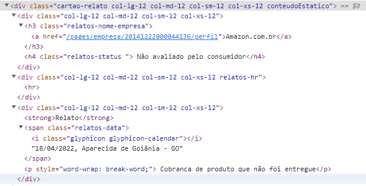

Next, we iterate over the cards and use the `xml_child` function of the package `xml2` to access the children of the parent nodes and the `html_text2` function of the `rvest` package to get the text from the elements. We then store the result in the database.

```r
for (i in 1:length(cards)){
      # Collects the names of the companies in each complaint ("relato")
      companyDB <- xml_child(xml_child(cards[[i]], 1), 1) %>% html_text2()

      # Collects the status of the complaints
      statusDB <- xml_child(xml_child(cards[[i]], 1), 2) %>% html_text2()

      # Collects date
      string <- xml_child(xml_child(cards[[i]], 3), 2) %>% html_text2()
      dateDB <- unlist(str_split(string, ','))[1]

      # Collects place
      placeDB <- unlist(str_split(string, ', '))[2]

      # Gets the complaints ("Relatos")
      complaintDB <- xml_child(xml_child(cards[[i]], 3), 3) %>% html_text2()

      # Inserts the data into the database
      sql <- sprintf({"INSERT INTO complaints (company, status, date, place, complaint) VALUES ('%s','%s','%s', '%s','%s')"}, companyDB, statusDB, dateDB, placeDB, complaintDB)

      # If the current attempt fails to insert the data, it will be skipped
      skip_to_next <- FALSE
      tryCatch({dbExecute(con, sql)},
               error = function(e) {
                 skip_to_next <<- TRUE
               })
      if(skip_to_next) { next }
      }
```

Finally, we can close the connection to the database and check whether the data were successfully stored in it:

```r
df <- dbReadTable(con, "complaints")
dbDisconnect(con)
glimpse(df)
```

[output not shown]